# About RFM segmentation

Customer segmentation is important for multiple reasons. We get a deeper knowledge of our customers and can tailor targeted marketing campaigns.

The RFM method was introduced by Bult and Wansbeek in 1995 and has been successfully used by marketers since. It analyzes customers' behavior on three parameters: Recency: How recent is the last purchase of the customer. Frequency: How often the customer makes a purchase. Monetary: How much money does the customer spends.

The advantages of RFM is that it is easy to implement and it can be used for different types of business. It helps craft better marketing campaigns and improves CRM and customer's loyalty.

The disadvantages are that it may not apply in industries where customers are usually one time buyers. It is based on historical data and won't give much insight about prospects.

In this post, I will show how we can use RFM segmentation with Python.

# Methodology

To get the RFM score of a customer, we need to first calculate the R, F and M scores on a scale from 1 (worst) to 5 (best).

-calculate Recency = number of days since last purchase -calculate Freqency = number of purchases during the studied period (usually one year) -calculate Monetary = total amount of purchases made during the studied period -find quintiles for each of these dimensions -give a grade to each dimension depending in which quintiles it stands -combine R, F and M scores to get the RFM score -map RF scores to segments -For this notebook, I will use the Online Retail dataset available on the UCI Machine Learning Repository.

# Calculcate the RFM score using Python

Import libraries

```python
import pandas as pd
import numpy as np
from datetime import timedelta
import matplotlib.pyplot as plt
```

load and prepare data

```python
sales = pd.read_excel('C:/Users/pc/Desktop/Datasets/Stock.xlsx')
sales.columns
```

```
Index(['InvoiceNo', 'StockCode', 'Description', 'Quantity', 'InvoiceDate',
       'UnitPrice', 'CustomerID', 'Country'],
      dtype='object')
```

```python
sales.describe()
```

|  | Quantity | UnitPrice | CustomerID |
| --- | --- | --- | --- |
| count | 541909.000000 | 541909.000000 | 406829.000000 |
| mean | 9.552250 | 4.611114 | 15287.690570 |
| std | 218.081158 | 96.759853 | 1713.600303 |
| min | -80995.000000 | -11062.060000 | 12346.000000 |
| 25% | 1.000000 | 1.250000 | 13953.000000 |
| 50% | 3.000000 | 2.080000 | 15152.000000 |
| 75% | 10.000000 | 4.130000 | 16791.000000 |
| max | 80995.000000 | 38970.000000 | 18287.000000 |

```python
sales.isnull().sum()
```

```
InvoiceNo           0
StockCode           0
Description      1454
Quantity            0
InvoiceDate         0
UnitPrice           0
CustomerID     135080
Country             0
dtype: int64
```

we can see from the above summary that description and customer ID have some null values. 135,080 invoices don't have a customer id

I am going to drop those lines as they will not help in our analysis of customers.

```python
sales.dropna(subset=['CustomerID'], inplace=True)
```

What is the time frame of the data we have?

```python
print('Orders from {} to {}'.format(sales['InvoiceDate'].min(),
                                    sales['InvoiceDate'].max()))
```

```
Orders from 2010-12-01 08:26:00 to 2011-12-09 12:50:00
```

We have about one year of sales data (from December 2010 to December 2011). This is the period usually used for RFM analysis. I'll set the period of the study to 365 days to get exactly one year.

I calculate the total price of each line.

```python
sales['Price'] = sales['Quantity'] * sales['UnitPrice']
```

Next, I control whether there's only one row per invoice.

```python
sales['InvoiceNo'].value_counts().head()
```

```
576339    542
579196    533
580727    529
578270    442
573576    435
Name: InvoiceNo, dtype: int64
```

Invoices can have multiple rows (one row per item).

However, I am interested in how many times did a customer purchase, not how many items did he buy. I want to count orders rather than items. I create an order dataframe that will aggregate our sales at the order level.

```python
orders = sales.groupby(['InvoiceNo', 'InvoiceDate', 'CustomerID']).agg({'Price': lambda x: x.sum()}).reset_index()
orders.head(10)
```

|  | InvoiceNo | InvoiceDate | CustomerID | Price |
| --- | --- | --- | --- | --- |
| 0 | 536365 | 2010-12-01 08:26:00 | 17850.0 | 139.12 |
| 1 | 536366 | 2010-12-01 08:28:00 | 17850.0 | 22.20 |
| 2 | 536367 | 2010-12-01 08:34:00 | 13047.0 | 278.73 |
| 3 | 536368 | 2010-12-01 08:34:00 | 13047.0 | 70.05 |
| 4 | 536369 | 2010-12-01 08:35:00 | 13047.0 | 17.85 |
| 5 | 536370 | 2010-12-01 08:45:00 | 12583.0 | 855.86 |
| 6 | 536371 | 2010-12-01 09:00:00 | 13748.0 | 204.00 |
| 7 | 536372 | 2010-12-01 09:01:00 | 17850.0 | 22.20 |
| 8 | 536373 | 2010-12-01 09:02:00 | 17850.0 | 259.86 |
| 9 | 536374 | 2010-12-01 09:09:00 | 15100.0 | 350.40 |

Finally, I am going to simulate an analysis I am doing in real time by setting the NOW date at one day after the last purchase. This date will be used as a reference to calculate the Recency score.

```python
NOW = orders['InvoiceDate'].max() + timedelta(days=1)
NOW
```

```
Timestamp('2011-12-10 12:50:00')
```

I am going to study the data over a period of one year. I set a period variable to 365 (days).

You can change this value depending on your needs. It will depend on the industry and the expected behavior of customers but one year is a commonly used value in RFM segmentation.

```python
period=365
```

# Calculate the Recency, Frequency and Monetary Value of each customers

To make things easier, I am going to add a column with the number of days between the purchase and now. To find the Recency values, I will just have to find the minimum of this column for each customer.

```python
orders['DaysSinceOrder'] = orders['InvoiceDate'].apply(lambda x: (NOW - x).days)
```

The scores are calculated for each customer. I need a dataframe with one row per customer. The scores will be stored in columns.

```python
aggr = {
    # the number of days since last order (Recency)
    'DaysSinceOrder': lambda x: x.min(),
    # the total number of orders in the last period (Frequency)
    'InvoiceDate': lambda x: len([d for d in x if d >= NOW - timedelta(days=period)]),
}
rfm = orders.groupby('CustomerID').agg(aggr).reset_index()
rfm.rename(columns={'DaysSinceOrder': 'Recency', 'InvoiceDate': 'Frequency'}, inplace=True)
rfm.head(10)
```

|  | CustomerID | Recency | Frequency |
| --- | --- | --- | --- |
| 0 | 12346.0 | 326 | 2 |
| 1 | 12347.0 | 2 | 6 |
| 2 | 12348.0 | 75 | 4 |
| 3 | 12349.0 | 19 | 1 |
| 4 | 12350.0 | 310 | 1 |
| 5 | 12352.0 | 36 | 11 |
| 6 | 12353.0 | 204 | 1 |
| 7 | 12354.0 | 232 | 1 |
| 8 | 12355.0 | 214 | 1 |
| 9 | 12356.0 | 23 | 3 |

```python
rfm.tail(10)
```

|  | CustomerID | Recency | Frequency |
| --- | --- | --- | --- |
| 4362 | 18273.0 | 2 | 3 |
| 4363 | 18274.0 | 18 | 2 |
| 4364 | 18276.0 | 21 | 3 |
| 4365 | 18277.0 | 58 | 2 |
| 4366 | 18278.0 | 74 | 1 |
| 4367 | 18280.0 | 278 | 1 |
| 4368 | 18281.0 | 181 | 1 |
| 4369 | 18282.0 | 8 | 3 |
| 4370 | 18283.0 | 4 | 16 |
| 4371 | 18287.0 | 43 | 3 |

I have the Recency and Frequency data. I need to add the Monetary value of each customer by adding sales over the last year.

```python
rfm['Monetary'] = rfm['CustomerID'].apply(lambda x: orders[(orders['CustomerID'] == x) & \
                                                           (orders['InvoiceDate'] >= NOW - timedelta(days=period))]\
                                                           ['Price'].sum())
rfm.head(10)
```

|  | CustomerID | Recency | Frequency | Monetary |
| --- | --- | --- | --- | --- |
| 0 | 12346.0 | 326 | 2 | 0.00 |
| 1 | 12347.0 | 2 | 6 | 3598.21 |
| 2 | 12348.0 | 75 | 4 | 1797.24 |
| 3 | 12349.0 | 19 | 1 | 1757.55 |
| 4 | 12350.0 | 310 | 1 | 334.40 |
| 5 | 12352.0 | 36 | 11 | 1545.41 |
| 6 | 12353.0 | 204 | 1 | 89.00 |
| 7 | 12354.0 | 232 | 1 | 1079.40 |
| 8 | 12355.0 | 214 | 1 | 459.40 |
| 9 | 12356.0 | 23 | 3 | 2811.43 |

```python
rfm.tail(10)
```

|  | CustomerID | Recency | Frequency | Monetary |
| --- | --- | --- | --- | --- |
| 4362 | 18273.0 | 2 | 3 | 204.00 |
| 4363 | 18274.0 | 18 | 2 | 0.00 |
| 4364 | 18276.0 | 21 | 3 | 323.36 |
| 4365 | 18277.0 | 58 | 2 | 97.63 |
| 4366 | 18278.0 | 74 | 1 | 173.90 |
| 4367 | 18280.0 | 278 | 1 | 180.60 |
| 4368 | 18281.0 | 181 | 1 | 80.82 |
| 4369 | 18282.0 | 8 | 3 | 176.60 |
| 4370 | 18283.0 | 4 | 16 | 2094.88 |
| 4371 | 18287.0 | 43 | 3 | 1837.28 |

# Calculate the R, F and M scores

We could also use quintiles. Each quintiles contains 20% of the population. Using quintiles is more flexible as the ranges will adapt to the data and would work across different industries or if there's any change in expected customer behavior. I am going to use the quintiles method. First, I get the quintiles for each parameter.

```python
quintiles = rfm[['Recency', 'Frequency', 'Monetary']].quantile([.2, .4, .6, .8]).to_dict()
quintiles
```

```
{'Recency': {0.2: 11.0, 0.4: 32.0, 0.6: 71.0, 0.8: 178.80000000000018},
 'Frequency': {0.2: 1.0, 0.4: 2.0, 0.6: 3.0, 0.8: 6.0},
 'Monetary': {0.2: 215.89800000000002,
  0.4: 440.432,
  0.6: 876.3679999999999,
  0.8: 1909.6580000000006}}
```

Then I write methods to assign ranks from 1 to 5. A smaller Recency value is better whereas higher Frequency and Monetary values are better. I need to write two separate methods.

```python
def r_score(x):
    if x <= quintiles['Recency'][.2]:
        return 5
    elif x <= quintiles['Recency'][.4]:
        return 4
    elif x <= quintiles['Recency'][.6]:
        return 3
    elif x <= quintiles['Recency'][.8]:
        return 2
    else:
        return 1

def fm_score(x, c):
    if x <= quintiles[c][.2]:
        return 1
    elif x <= quintiles[c][.4]:
        return 2
    elif x <= quintiles[c][.6]:
        return 3
    elif x <= quintiles[c][.8]:
        return 4
    else:
        return 5
```

I am now ready to get the R, F and M scores of each customer.

```python
rfm['R'] = rfm['Recency'].apply(lambda x: r_score(x))
rfm['F'] = rfm['Frequency'].apply(lambda x: fm_score(x, 'Frequency'))
rfm['M'] = rfm['Monetary'].apply(lambda x: fm_score(x, 'Monetary'))
```

# Get customers segments from RFM score

Finally, I combine the R, F and M scores into a RFM Score.

```python
rfm['RFM Score'] = rfm['R'].map(str) + rfm['F'].map(str) + rfm['M'].map(str)
rfm.head(10)
```

|  | CustomerID | Recency | Frequency | Monetary | R | F | M | RFM Score |
| --- | --- | --- | --- | --- | --- | --- | --- | --- |
| 0 | 12346.0 | 326 | 2 | 0.00 | 1 | 2 | 1 | 121 |
| 1 | 12347.0 | 2 | 6 | 3598.21 | 5 | 4 | 5 | 545 |
| 2 | 12348.0 | 75 | 4 | 1797.24 | 2 | 4 | 4 | 244 |
| 3 | 12349.0 | 19 | 1 | 1757.55 | 4 | 1 | 4 | 414 |
| 4 | 12350.0 | 310 | 1 | 334.40 | 1 | 1 | 2 | 112 |
| 5 | 12352.0 | 36 | 11 | 1545.41 | 3 | 5 | 4 | 354 |
| 6 | 12353.0 | 204 | 1 | 89.00 | 1 | 1 | 1 | 111 |
| 7 | 12354.0 | 232 | 1 | 1079.40 | 1 | 1 | 4 | 114 |
| 8 | 12355.0 | 214 | 1 | 459.40 | 1 | 1 | 3 | 113 |
| 9 | 12356.0 | 23 | 3 | 2811.43 | 4 | 3 | 5 | 435 |

```python
rfm.tail(10)
```

|  | CustomerID | Recency | Frequency | Monetary | R | F | M | RFM Score |
| --- | --- | --- | --- | --- | --- | --- | --- | --- |
| 4362 | 18273.0 | 2 | 3 | 204.00 | 5 | 3 | 1 | 531 |
| 4363 | 18274.0 | 18 | 2 | 0.00 | 4 | 2 | 1 | 421 |
| 4364 | 18276.0 | 21 | 3 | 323.36 | 4 | 3 | 2 | 432 |
| 4365 | 18277.0 | 58 | 2 | 97.63 | 3 | 2 | 1 | 321 |
| 4366 | 18278.0 | 74 | 1 | 173.90 | 2 | 1 | 1 | 211 |
| 4367 | 18280.0 | 278 | 1 | 180.60 | 1 | 1 | 1 | 111 |
| 4368 | 18281.0 | 181 | 1 | 80.82 | 1 | 1 | 1 | 111 |
| 4369 | 18282.0 | 8 | 3 | 176.60 | 5 | 3 | 1 | 531 |
| 4370 | 18283.0 | 4 | 16 | 2094.88 | 5 | 5 | 5 | 555 |
| 4371 | 18287.0 | 43 | 3 | 1837.28 | 3 | 3 | 4 | 334 |

# The RFM scores give us 5^3 = 125 segments. Which is not easy to work with.

Segment Description

Champions Bought recently, buy often and spend the most

Loyal Customers Buy on a regular basis. Responsive to promotions.

Potential Loyalist Recent customers with average frequency.

Recent Customers Bought most recently, but not often.

Promising Recent shoppers, but haven’t spent much.

Customers Needing Attention Above average recency, frequency and monetary values. May not have bought very recently though.

About To Sleep Below average recency and frequency. Will lose them if not reactivated.

At Risk Purchased often but a long time ago. Need to bring them back!

Can’t Lose Them Used to purchase frequently but haven’t returned for a long time.

Hibernating Last purchase was long back and low number of orders. May be lost.

```python
![rfm-segments.png](attachment:rfm-segments.png) # insert an image
```

[output not shown]

```python
segt_map = {
    r'[1-2][1-2]': 'hibernating',
    r'[1-2][3-4]': 'at risk',
    r'[1-2]5': 'can\'t loose',
    r'3[1-2]': 'about to sleep',
    r'33': 'need attention',
    r'[3-4][4-5]': 'loyal customers',
    r'41': 'promising',
    r'51': 'new customers',
    r'[4-5][2-3]': 'potential loyalists',
    r'5[4-5]': 'champions'
}

rfm['Segment'] = rfm['R'].map(str) + rfm['F'].map(str)
rfm['Segment'] = rfm['Segment'].replace(segt_map, regex=True)
rfm.head(10)
```

|  | CustomerID | Recency | Frequency | Monetary | R | F | M | RFM Score | Segment |
| --- | --- | --- | --- | --- | --- | --- | --- | --- | --- |
| 0 | 12346.0 | 326 | 2 | 0.00 | 1 | 2 | 1 | 121 | hibernating |
| 1 | 12347.0 | 2 | 6 | 3598.21 | 5 | 4 | 5 | 545 | champions |
| 2 | 12348.0 | 75 | 4 | 1797.24 | 2 | 4 | 4 | 244 | at risk |
| 3 | 12349.0 | 19 | 1 | 1757.55 | 4 | 1 | 4 | 414 | promising |
| 4 | 12350.0 | 310 | 1 | 334.40 | 1 | 1 | 2 | 112 | hibernating |
| 5 | 12352.0 | 36 | 11 | 1545.41 | 3 | 5 | 4 | 354 | loyal customers |
| 6 | 12353.0 | 204 | 1 | 89.00 | 1 | 1 | 1 | 111 | hibernating |
| 7 | 12354.0 | 232 | 1 | 1079.40 | 1 | 1 | 4 | 114 | hibernating |
| 8 | 12355.0 | 214 | 1 | 459.40 | 1 | 1 | 3 | 113 | hibernating |
| 9 | 12356.0 | 23 | 3 | 2811.43 | 4 | 3 | 5 | 435 | potential loyalists |

```python
rfm.tail(10)
```

|  | CustomerID | Recency | Frequency | Monetary | R | F | M | RFM Score | Segment |
| --- | --- | --- | --- | --- | --- | --- | --- | --- | --- |
| 4362 | 18273.0 | 2 | 3 | 204.00 | 5 | 3 | 1 | 531 | potential loyalists |
| 4363 | 18274.0 | 18 | 2 | 0.00 | 4 | 2 | 1 | 421 | potential loyalists |
| 4364 | 18276.0 | 21 | 3 | 323.36 | 4 | 3 | 2 | 432 | potential loyalists |
| 4365 | 18277.0 | 58 | 2 | 97.63 | 3 | 2 | 1 | 321 | about to sleep |
| 4366 | 18278.0 | 74 | 1 | 173.90 | 2 | 1 | 1 | 211 | hibernating |
| 4367 | 18280.0 | 278 | 1 | 180.60 | 1 | 1 | 1 | 111 | hibernating |
| 4368 | 18281.0 | 181 | 1 | 80.82 | 1 | 1 | 1 | 111 | hibernating |
| 4369 | 18282.0 | 8 | 3 | 176.60 | 5 | 3 | 1 | 531 | potential loyalists |
| 4370 | 18283.0 | 4 | 16 | 2094.88 | 5 | 5 | 5 | 555 | champions |
| 4371 | 18287.0 | 43 | 3 | 1837.28 | 3 | 3 | 4 | 334 | need attention |

# Visualize our customers segments

Now that we have our scores, we can do some data visualization to get a better idea of our customers portfolio. First, let see at the distribution of R, F and M.

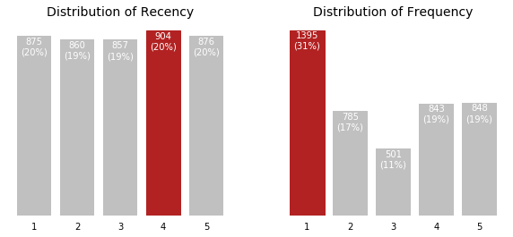

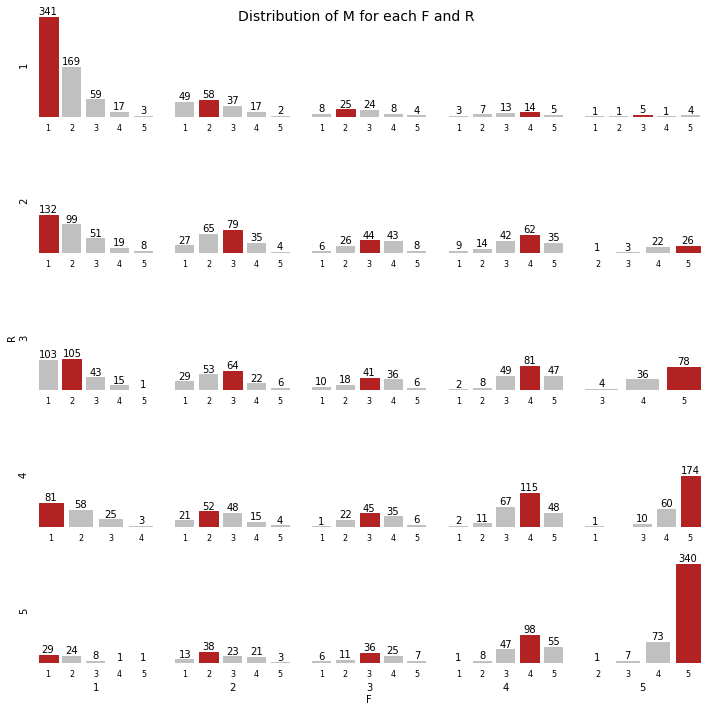

```python
# plot the distribution of customers over R and F
fig, axes = plt.subplots(nrows=1, ncols=2, figsize=(10, 4))

for i, p in enumerate(['R', 'F']):
    parameters = {'R':'Recency', 'F':'Frequency'}
    y = rfm[p].value_counts().sort_index()
    x = y.index
    ax = axes[i]
    bars = ax.bar(x, y, color='silver')
    ax.set_frame_on(False)
    ax.tick_params(left=False, labelleft=False, bottom=False)
    ax.set_title('Distribution of {}'.format(parameters[p]),
                fontsize=14)
    for bar in bars:
        value = bar.get_height()
        if value == y.max():
            bar.set_color('firebrick')
        ax.text(bar.get_x() + bar.get_width() / 2,
                value - 5,
                '{}\n({}%)'.format(int(value), int(value * 100 / y.sum())),
               ha='center',
               va='top',
               color='w')

plt.show()

# plot the distribution of M for RF score
fig, axes = plt.subplots(nrows=5, ncols=5,
                         sharex=False, sharey=True,
                         figsize=(10, 10))

r_range = range(1, 6)
f_range = range(1, 6)
for r in r_range:
    for f in f_range:
        y = rfm[(rfm['R'] == r) & (rfm['F'] == f)]['M'].value_counts().sort_index()
        x = y.index
        ax = axes[r - 1, f - 1]
        bars = ax.bar(x, y, color='silver')
        if r == 5:
            if f == 3:
                ax.set_xlabel('{}\nF'.format(f), va='top')
            else:
                ax.set_xlabel('{}\n'.format(f), va='top')
        if f == 1:
            if r == 3:
                ax.set_ylabel('R\n{}'.format(r))
            else:
                ax.set_ylabel(r)
        ax.set_frame_on(False)
        ax.tick_params(left=False, labelleft=False, bottom=False)
        ax.set_xticks(x)
        ax.set_xticklabels(x, fontsize=8)

        for bar in bars:
            value = bar.get_height()
            if value == y.max():
                bar.set_color('firebrick')
            ax.text(bar.get_x() + bar.get_width() / 2,
                    value,
                    int(value),
                    ha='center',
                    va='bottom',
                    color='k')
fig.suptitle('Distribution of M for each F and R',
             fontsize=14)
plt.tight_layout()
plt.show()
```

We can see that if recency seems evenly distributed, almost half of the customers don't purchase very often (48% of customers have a frequency of 1 or 2). When looking at the monetary value, we see that the customers spending the most are those with the highest activity (R and F of 4-5). We have very few large orders (high monetary value but low frequency).

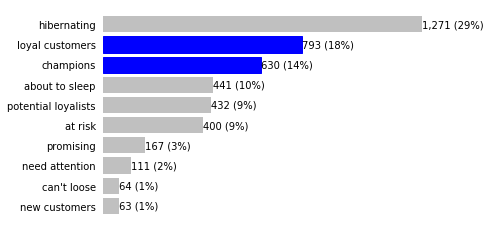

```python
# count the number of customers in each segment
segments_counts = rfm['Segment'].value_counts().sort_values(ascending=True)

fig, ax = plt.subplots()

bars = ax.barh(range(len(segments_counts)),
              segments_counts,
              color='silver')
ax.set_frame_on(False)
ax.tick_params(left=False,
               bottom=False,
               labelbottom=False)
ax.set_yticks(range(len(segments_counts)))
ax.set_yticklabels(segments_counts.index)

for i, bar in enumerate(bars):
        value = bar.get_width()
        if segments_counts.index[i] in ['champions', 'loyal customers']:
            bar.set_color('BLUE')
        ax.text(value,
                bar.get_y() + bar.get_height()/2,
                '{:,} ({:}%)'.format(int(value),
                                   int(value*100/segments_counts.sum())),
                va='center',
                ha='left'
               )

plt.show()
```

# CONCLUSION & RECCOMENDATION

Further analysis can be done that integrate the Monetary parameters. With customers assigned to segments and some statistics on the composition of our customers portfolio, we can work on targeted marketing campaigns to retain customers that are at risk, improve sales to customers with some potential and reward the best customers.

# REGARDS

@Owinoh_victor_Author @Guillaume Martin-for the guide on using RFM..... This notebook was created as my vizualization practise for Matplotlib. copyright is granted to anyone willing to use,distribute,publish or commercialize